# Introduction to SC19062

By 19062

2020-01-02

## Overview

**SC19062** is a simple R package including mainly two functions and some homework answers for the ‘Statistical Computing’ course. One is EM algorithm for Gaussian mixture models. The other is PSEVE procedure, a robust estimating method in semiparametric partially linear errors-in-variables model. Examples of how to use these two functions are as follows:

```r
library(SC19062)
#initial values of parameters
mu<-matrix(c(2,4,50,80),2,2)
sigma1<-matrix(c(1,0,0,1),2,2)
sigma2<-matrix(c(1,0,0,1),2,2)
prop<-c(0.5,2)
#outcomes
EM(data,mu,sigma1,sigma2,prop)
```

```
## $mu
##          [,1]     [,2]
## [1,] 2.036388 54.47852
## [2,] 4.289662 79.96812
##
## $sigma1
##            eruptions    waiting
## eruptions 0.06916767  0.4351676
## waiting   0.43516762 33.6972821
##
## $sigma2
##           eruptions    waiting
## eruptions 0.1699684  0.9406093
## waiting   0.9406093 36.0462113
##
## $prop
## [1] 0.3558729 0.6441271
```

Then is an example of function *PLMEV*.

```r
n=200
z1 <- rnorm(n)
z2 <- rnorm(n)
eps <- rnorm(n,0,0.2)
eps1 <- rnorm(n,0,0.2)
eps2 <- rnorm(n,0,0.2)
xx <- cbind(z1,z2)
xt <- runif(n,-6,6)
vv <- cbind(z1+eps1,z2+eps2)
y <- 2*xx[,1] + xx[,2] + cos(pi*xt/6) + eps
gg <- cos(pi*xt/6)
## ventana= smoothing parameter
## the kernel is scaled so that their quartiles
## (viewed as probability densities) are at +/- 0.25*ventana
## The smoothing bandwidth = 0.25*ventana/0.675
ventana=2.5
salida=PLMEV(y,vv,xt,palabra="mcd",cw=0.975,k=0.55,ventana)
salida$beta.rob
```

```
## [1] 1.977335 1.038054
```

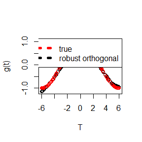

```r
plot(xt,salida$ghat,xlab='T',ylab='g(t)')
points(xt,gg,col="red")
legend('topright' , legend = c('true' , 'robust orthogonal') , col = c('red', 'black') , lty = 3 , lwd = 5)
```

We also plot the estimated curve here compared to the true line.

At last, we state the homework answers.

## Homework-2019-09-20

We want to use knitr to produce at least 3 examples (texts, figures, tables) in this homework.

### Example 1

Dataset “scor” in package “bootstrap” contains grades of 5 exams of 88 students: mechanics, vectors, algebra, analysis, ststistics. We want to scan the data in table.

```r
library(bootstrap)
data(scor)
knitr::kable(scor)   #scan the data in table
```

| mec | vec | alg | ana | sta |
| --- | --- | --- | --- | --- |
| 77 | 82 | 67 | 67 | 81 |
| 63 | 78 | 80 | 70 | 81 |
| 75 | 73 | 71 | 66 | 81 |
| 55 | 72 | 63 | 70 | 68 |
| 63 | 63 | 65 | 70 | 63 |
| 53 | 61 | 72 | 64 | 73 |
| 51 | 67 | 65 | 65 | 68 |
| 59 | 70 | 68 | 62 | 56 |
| 62 | 60 | 58 | 62 | 70 |
| 64 | 72 | 60 | 62 | 45 |
| 52 | 64 | 60 | 63 | 54 |
| 55 | 67 | 59 | 62 | 44 |
| 50 | 50 | 64 | 55 | 63 |
| 65 | 63 | 58 | 56 | 37 |
| 31 | 55 | 60 | 57 | 73 |
| 60 | 64 | 56 | 54 | 40 |
| 44 | 69 | 53 | 53 | 53 |
| 42 | 69 | 61 | 55 | 45 |
| 62 | 46 | 61 | 57 | 45 |
| 31 | 49 | 62 | 63 | 62 |
| 44 | 61 | 52 | 62 | 46 |
| 49 | 41 | 61 | 49 | 64 |
| 12 | 58 | 61 | 63 | 67 |
| 49 | 53 | 49 | 62 | 47 |
| 54 | 49 | 56 | 47 | 53 |
| 54 | 53 | 46 | 59 | 44 |
| 44 | 56 | 55 | 61 | 36 |
| 18 | 44 | 50 | 57 | 81 |
| 46 | 52 | 65 | 50 | 35 |
| 32 | 45 | 49 | 57 | 64 |

[output cut: 58 more lines]

### Example 2

We want to display a time series plot of the annual rainfal amounts recorded in Los Angeles, Carlifornia, over more than 100 years. We are interested in whether or not consecutive years are related in some way.

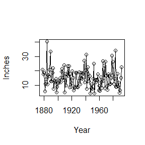

```r
library(TSA)
#win.graph(width=4.875,height=2.5,pointsize=8)
data(larain)
plot(larain,ylab='Inches',xlab='Year',type='o')
```

The plot shows considerable variation in rainfall amount over the years - some years are low, some high, and many are in-between in value. Therefore, we plot a scatterplot for rainfall in the next figure. However, it shows that there is little if any information about this year’s rainfall amount from last year’s amount.

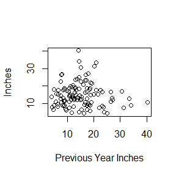

```r
#win.graph(width=3,height=3,pointsize=8)
plot(y=larain,x=zlag(larain),ylab='Inches',xlab='Previous Year Inches')
```

### Example 3

The data contains 12780 observations of 3 variables about biology. We want to make a cluster analysis.

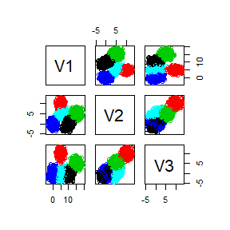

```r
library(SC19062)
data("data1")
cl<-kmeans(data,5)    #using k-means algorithm
plot(data,col=cl$cluster)
```

Here we divide the data into 5 clusters using k-means algorithm. In fact, the outcome is pretty good comparing with the ture cluster.

## Homework-2019-09-29

This homework is about generating random samples from same specific distributions.

### Qusetion 1

The Rayleigh density is

$$f(x)=\frac{x}{\sigma^2}e^{-\frac{x^2}{2\sigma^2}},\qquad x\geq b>0, a>0$$

Develop an algorithm to generate random samples from a Rayleigh($\sigma$) distribution. Generate Rayleigh($\sigma$) samples for several choices of $\sigma>0$ and check that the mode of the generated samples is close to the theoretical mode $\sigma$ (check the histogram).

### Answer 1

We can use inverse transformation method to generate random samples from a Rayleigh($\sigma$) distribution. The cdf of this distribution is
$$F(x)=1-e^{-\frac{x^2}{2\sigma^2}}, \qquad x\geq 0$$
Therefore, the inverse transformation is
$$F_{X}^{-1}(U)=\sigma\sqrt{-2log(1-u)}$$
Note that U and 1-U have the same distribution and it is simpler to set $x=\sigma\sqrt{-2log(u)}$. The R code is as follows:

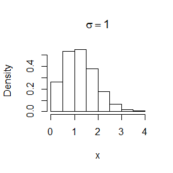

```r
n<-1000
set.seed(1234)
u<-runif(n)   #generate random samples from U(0,1)
sigma<-c(1,2,3)
x<-sigma[1]*sqrt(-2*log(u))  #generate random samples when sigma=1
y<-sigma[2]*sqrt(-2*log(u))  #generate random samples when sigma=2
z<-sigma[3]*sqrt(-2*log(u))  #generate random samples when sigma=3
#plot histograms
hist(x,prob=TRUE,main=expression(sigma==1))
```

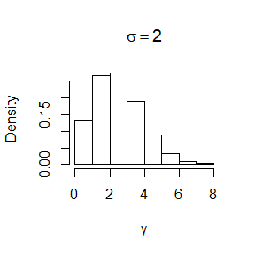

```r
hist(y,prob=TRUE,main=expression(sigma==2))
```

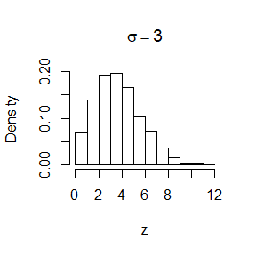

```r
hist(z,prob=TRUE,main=expression(sigma==3))
```

We generate Rayleigh($\sigma$) samples for three choices of $\sigma$ and plot the histograms of them. From the figures, we can see that the modes of the generated samples are about 1, 2 and 3, respectively. They are close to the theoretical modes when $\sigma=1$, $\sigma=2$ and $\sigma=3$.

### Question 2

Generate a random sample of size 1000 from a normal location mixture. The components of the mixture have N(0,1) and N(3,1) distributions with mixing probabilities $p_1$ and $p_2=1-p_1$. Graph the histogram of the sample with density superimposed, for $p_1=0.75$. Repeat with different values for $p_1$ and observe whether the emperical distribution of the mixture appears to be bimodal. Make a conjecture about the values of $p_1$ that produe bimodal mixtures.

### Answer 2

[figure not shown]

```r
n<-1000
set.seed(1234)
x1<-rnorm(n,0,1)
x2<-rnorm(n,3,1)
p1<-c(0.75,0.8,0.7,0.65,0.6,0.55)
par(mfcol=c(2,3))  #prepare to plot histograms of different values of p1 in one figure
for (i in 1:6) {
  r<-sample(c(0,1),n,replace=TRUE,prob=c(1-p1[i],p1[i]))
  z<-r*x1+(1-r)*x2
  hist(z,prob=TRUE,ylim=c(0,.3),main=p1[i])   #plot the histograms
  lines(density(z))  #lines the density curve
}
```

From the figures produced above, we can see that when p1=0.75, the emperical distribution of the mixture appears to be bimodal. However, when p1 is about 0.55, it is more obvious that we produce bimodal mixtures.

### Qusetion 3

Write a function to generate a random sample from a $W_d(\Sigma,n)$(Wishart) distribution for $n>d+1\geq 1$, based on Bartlett’s decomposition.

### Answer 3

```r
#generate a random sample from Wishart distribution
x<-function(sigma,n){
  d<-dim(sigma)[1]  #compute dimension d
  L<-t(chol(sigma)) #compute Choleski factorization of sigma
  #generate matrix T based on Bartlett's decomposition
  z<-rnorm(d^2)
  T<-matrix(z,d,d)
  T[upper.tri(T)]=0
  diag<-numeric(d)
  for (i in 1:d) {
    diag[i]<-rchisq(1,n-i+1)
    T[i,i]=diag[i]
  }
  A=T%*%t(T)
  #generate a random sample
  sample<-L%*%A%*%t(L)
  sample
}
```

## Homework-2019-10-11

This homework is about Monte Carlo methods.

### Question 1

Compute a Monte Carlo estimate of
$$\int_0^{\pi/3}sintdt$$
and compare your estimate with the exact value of the integral.

### Answer 1

```r
m<-1e4
set.seed(1234)
# simple Monte Carlo
x<-runif(m,0,pi/3)
theta.hat<-mean(sin(x))*pi/3
print(c(theta.hat,1-cos(pi/3)))
```

```
## [1] 0.5005534 0.5000000
```

We can see that one Monte Carlo estimate of this integral is 0.5005534, very closed to the exact value is 0.5.

### Question 2

Use Monte Carlo intergration with antithetic variables to estimate
$$\int_0^{1} \frac{e^{-x}}{1+x^2}dx$$
and find the approximate reduction in variance as a percentage of the variance without variance reduction.

### Answer 2

```r
m<-1e4
set.seed(1234)
x<-runif(m/2)
theta.hat<-mean(c(exp(-x)/(1+x^2),exp(x-1)/(1+(1-x)^2)))
print(theta.hat)
```

```
## [1] 0.5246322
```

Here our estimate of the intergration by antithetic variables is equal to 0.5246322. Then we want to find the approximate reduction in variance.

```r
# compute variances
n<-1000
MC1<-MC2<-numeric(n)
for (i in 1:n) {
  x<-runif(m)
  y<-runif(m/2)
  MC1[i]<-mean(exp(-x)/(1+x^2))
  MC2[i]<-mean(c(exp(-y)/(1+y^2),exp(y-1)/(1+(1-y)^2)))
}
print(c(var(MC2)/var(MC1),(var(MC1)-var(MC2))/var(MC1)))
```

```
## [1] 0.03619831 0.96380169
```

We can see that the antithetic variable approach achieved approximately 96.38% reduction in variance, which is unbelivable!

### Question 3

Obtain the stratified importance sampling estimate in Example 5.13 and compare it with the result of Example 5.10.

### Answer 3

```r
m<-1e4    # number of replicates
set.seed(1234)
k<-5      # number of strata
r<-m/k
N<-50     # number of times to repeat the estimation
T2<-numeric(k)
estimates<-matrix(0,N,2)
g<-function(x) {
  exp(-x)/(1+x^2)*(x>0)*(x<1)
}
for (i in 1:N) {
  u1<-runif(m)
  x<--log(1-u1*(1-exp(-1)))    # inverse transformated method
  fg1<-g(x)/(exp(-x)/(1-exp(-1)))
  estimates[i,1]<-mean(fg1)
  for (j in 1:k) {
    u<-c(0,0.2,0.4,0.6,0.8,1)
    quintile<--log(1-u*(1-exp(-1)))   # compute quintiles
    u2<-runif(m/5)
    y<--log(exp(-quintile[j])-u2/5*(1-exp(-1)))
    fg2<-g(y)/(5*exp(-y)/(1-exp(-1)))
    T2[j]<-mean(fg2)
  }
  estimates[i,2]<-sum(T2)
}
print(estimates)
```

```
##            [,1]      [,2]
##  [1,] 0.5249988 0.5246043
##  [2,] 0.5233420 0.5252055
##  [3,] 0.5248668 0.5248707
##  [4,] 0.5227322 0.5245440
##  [5,] 0.5244643 0.5251637
##  [6,] 0.5261013 0.5249735
##  [7,] 0.5251024 0.5249708
##  [8,] 0.5246194 0.5249072
##  [9,] 0.5241697 0.5248848
## [10,] 0.5244128 0.5244162
## [11,] 0.5234343 0.5248732
## [12,] 0.5253935 0.5247433
## [13,] 0.5253712 0.5250555
## [14,] 0.5257074 0.5247928
```

[output cut: 36 more lines]

```r
apply(estimates,2,mean)
```

```
## [1] 0.5248017 0.5248071
```

```r
apply(estimates,2,var)
```

```
## [1] 6.774234e-07 3.564106e-08
```

```r
print((var(estimates[,1])-var(estimates[,2]))/var(estimates[,1]))
```

```
## [1] 0.9473873
```

We can see that the stratified importance sampling approach achieved approximately 94.74% reduction in variance.

## Homework-2019-10-18

This homework is about Monte Carlo experiment.

### Question 1

Suppose a 95% symmetric t-interval is applied to estimate a mean, but the sample data are non-normal. Then the probability that the confidence interval covers the mean is not necessarily equal to 0.95. Use a Monte Carlo experiment to estimate the coverage probability of the t-interval for random samples of $\chi^2(2)$ data with sample size n=20. Compare your t-interval results with the simulation results in Example 6.4. (The t-interval should be more robust to departures from normality than the interval for variance.)

### Answer 1

```r
n<-20       #sample size
alpha<-.05  #confidence level
m<-1000     #replicates
LCL<-UCL<-numeric(m)
set.seed(1234)
#compute LCL and UCL for each replicate
for (i in 1:1000) {
  x<-rchisq(n,2)
  LCL[i]<-mean(x)-qt(1-alpha/2,n-1)*sd(x)/sqrt(n)
  UCL[i]<-mean(x)+qt(1-alpha/2,n-1)*sd(x)/sqrt(n)
}
#compute the probability that the confidence interval covers the mean
mean((LCL<2)*(UCL>2))
```

```
## [1] 0.909
```

In this experiment, 90.9% of the intervals contained the popupation mean, which is less than the 95% coverage under normality. However, when compared to Example 6.4 estimating the interval for variance, this outcome is better while only 77.3% of the intervals contained the population variance. We can see that the t-interval for mean is more robust to departures from normality than the chi-square-interval for variance.

### Question 2

Estimate the 0.025, 0.05, 0.95 and 0.975 quantiles of the skewness $\sqrt{b1}$ under normality by a Monte Carlo experiment. Compute the standard error of the estimates from (2.14) using the normal approximation for the density (with exact variance formula). Compare the estimated quantiles with the quantiles of the large sample approximation $\sqrt{b1}\approx N(0,6/n)$.

### Answer 2

```r
library(moments)  #to use function 'skewness' in this package
set.seed(1234)
n<-1000    #sample size
m<-1000
k<-100    #replicates
q<-c(0.025,0.05,0.95,0.975)   #four quantiles
quantile<-matrix(0,k,4)
#MC experiments to generate k replicates of estimate under normality
for (i in 1:k) {
  b1<-replicate(m,expr={
    x<-rnorm(n)
    skewness(x)
  })
  quantile[i,1]<-quantile(b1,q[1])
  quantile[i,2]<-quantile(b1,q[2])
  quantile[i,3]<-quantile(b1,q[3])
  quantile[i,4]<-quantile(b1,q[4])
}
quantile_sample<-c(c(mean(quantile[,1]),mean(quantile[,2]),mean(quantile[,3]),mean(quantile[,4])))
print(quantile_sample)
```

```
## [1] -0.1514428 -0.1272898  0.1261646  0.1510839
```

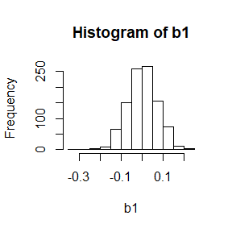

```r
hist(b1)
```

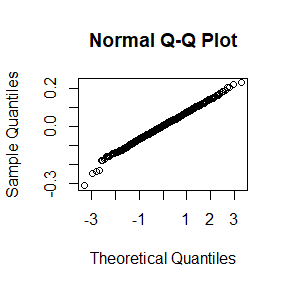

```r
qqnorm(b1)
```

Here we draw the histogram of one sample skewness, and from the histogram we can see that it is close to normal distribution. Then we plot qq-plot and find that our assumption is true.

```r
se<-numeric(4)
#compute se using (2.14) formula
for(i in 1:4) {
  se[i]<-sqrt(q[i]*(1-q[i])/(m*dnorm(quantile_sample[i],0,sqrt(6/n))))
}
print(se)
```

```
## [1] 0.005656873 0.005965229 0.005894766 0.005631340
```

The se of the estimators computing by (2.14) are very small.

```r
#estimate quantiles using large sample approximation
quantile_large<-numeric(4)
for (i in 1:4) {
  quantile_large[i]<-qnorm(q[i],0,sqrt(6/n))
}
print(quantile_large)
```

```
## [1] -0.1518182 -0.1274098  0.1274098  0.1518182
```

```r
knitr::kable(rbind(quantile_sample,quantile_large),col.names=c(0.025,0.05,0.95,0.975))
```

|  | 0.025 | 0.05 | 0.95 | 0.975 |
| --- | --- | --- | --- | --- |
| quantile_sample | -0.1514428 | -0.1272898 | 0.1261646 | 0.1510839 |
| quantile_large | -0.1518182 | -0.1274098 | 0.1274098 | 0.1518182 |

The estimated quantiles using large sample approximation are very close to the outcomes using MC experiments under normality.

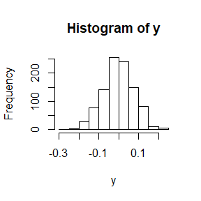

```r
y<-rnorm(n,0,sqrt(6/n))
hist(y)
```

Here we plot the histogram of normal distribution and find that it is close to the former histogram, which means it is reasonable that sample skewness follows normal distribution.

## Homework-2019-11-01

This homework is about using Monte Carlo simulation to estimate the power of a hypothesis test.

### Question 1

Estimate the power of the skewness test of normality against symmetric Beta($\alpha$,$\alpha$) distributions and comment on the results. Are the results different for heavy-tailed symmetric alternatives such as t($\nu$)?

### Answer 1

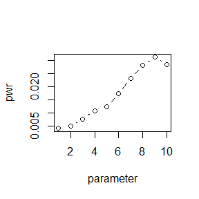

```r
alpha<-0.05
set.seed(1234)
n<-30
m<-2500
parameter<-1:10
N<-length(parameter)
pwr<-numeric(N)
# critical value for the skewness test
cv<-qnorm(1-alpha/2,0,sqrt(6*(n-2)/((n+1)*(n+3))))

# define sk
sk<-function(x) {
  #compute the sample skewness coeff
  xbar<-mean(x)
  m3<-mean((x-xbar)^3)
  m2<-mean((x-xbar)^2)
  return(m3/m2^1.5)
}


for (j in 1:N) {
  p<-parameter[j]
  sktests<-numeric(m)
  for (i in 1:m) {
    x<-rbeta(n,p,p)
    sktests[i]<-as.integer(abs(sk(x))>=cv)
  }
  pwr[j]<-mean(sktests)
}

#plot power vs parameter
plot(parameter,pwr,type='b')
```

The power of the skewness test of normality against symmetric Beta($\alpha$,$\alpha$) distributions is very small, which means that this test is not good enough for testing whether the distribution satisfies normality under symmetric Beta distribution. The power shows an upward trend as the value of parameters increases. However, the power of the skewness test of normality against t distribution can be large. And the power shows an downward trend as the value of parameters increases, which is different from Beta distribution.

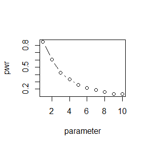

```r
for (j in 1:N) {
  p<-parameter[j]
  sktests<-numeric(m)
  for (i in 1:m) {
    y<-rt(n,p)
    sktests[i]<-as.integer(abs(sk(y))>=cv)
  }
  pwr[j]<-mean(sktests)
}
plot(parameter,pwr,type='b')
```

### Question 2

Use Monte Carlo simulation to investigate whether the empirical Type I error rate of the t-test is approximately equal to nominal significance level $\alpha$, when the sampled population is non-normal. The t-test is robust to mild departures from normality. Discuss the simulation results for the cases where the sampled population is (i) $\chi^2(1)$, (ii) Uniform(0,2), and (iii) Exponential(rate=1). In each case, test $H_0:\mu=\mu_0$ vs $H_1:\mu \neq \mu_0$, where $\mu_0$ is the mean of $\chi^2(1)$, Uniform(0,2), and Exponential(1), respectively.